# DATA607_WEEK9_API

Farhod Ibragimov

2025-03-29

## Loading libraries

```r
library(tidyverse)
library(httr)
library(jsonlite)
library(readr)
library(tidytext)
```

```r
library(ggplot2)
```

- `httr`**:** Provides functions for working with HTTP, making it easy to send GET, POST, and other HTTP requests.
- `jsonlite`**:** Offers tools for parsing JSON data into R objects (like lists or data frames) and converting R objects into JSON.

## Setting API URL and API key

`api_key` includes API key.

```r
api_key <- Sys.getenv("NYT_API_KEY")
api_url <- paste0("https://api.nytimes.com/svc/mostpopular/v2/viewed/30.json?api-key=", api_key)
```

## Sending GET request to the NYT API

```r
response <- GET(api_url)
```

`GET:`this function from `httr`package sends `HTTP GET` request to the URL defined by `api_url`.

The result of the response is stored in `response` variable. It includes status information, headers, and the body of the response.

## Checking the response status

```r
if(status_code(response) == 200) {
  json_data <- content(response, as = "text", encoding = "UTF-8")
  data_list <- fromJSON(json_data, flatten = TRUE)
}else {
  print("Error: Unable to fetch data from API")
}
```

`status_code(response)`retrieves the HTTP status code from the response.

`200`**:** Indicates a successful request. If the status code is 200, the code proceeds to parse the content. Otherwise, it prints an error message.

## Extracting and parsing the JSON content:

```r
json_data <- content(response, as = "text", encoding = "UTF-8")
data_list <- fromJSON(json_data, flatten = TRUE)
print(data_list)
```

```
## $status
## [1] "OK"
##
## $copyright
## [1] "Copyright (c) 2025 The New York Times Company.  All Rights Reserved."
##
## $num_results
## [1] 20
##
## $results
##                                                       uri
## 1      nyt://article/2180670d-3746-549a-b8c1-aeeb232afbe1
## 2      nyt://article/f6a45e9b-1f77-5f75-b538-3e95c72a5db6
## 3      nyt://article/b831afe8-eda5-53c0-ba24-697237038399
## 4      nyt://article/9e53daea-f06f-537b-b5fc-e629f10eead2
```

[output cut: 331 more lines]

Here the code extracts the body of response as a text string.

`UTF-8`ensures that characters are correctly interpreted.

`fromJSON`converts the JSON text into `data_list`using `jsonlite.`

## Converting data into a dataframe:

```r
articles_df <- as.data.frame(data_list$results)
```

The API’s JSON response typically contains a key called `results` where the actual articles or items are stored.

## Displaying the dataframe:

```r
glimpse(articles_df)
```

```
## Rows: 20
## Columns: 22
## $ uri            <chr> "nyt://article/2180670d-3746-549a-b8c1-aeeb232afbe1", "…
## $ url            <chr> "https://www.nytimes.com/2025/03/07/us/politics/trump-m…
## $ id             <dbl> 1e+14, 1e+14, 1e+14, 1e+14, 1e+14, 1e+14, 1e+14, 1e+14,…
## $ asset_id       <dbl> 1e+14, 1e+14, 1e+14, 1e+14, 1e+14, 1e+14, 1e+14, 1e+14,…
## $ source         <chr> "New York Times", "New York Times", "New York Times", "…
## $ published_date <chr> "2025-03-07", "2025-02-27", "2025-03-14", "2025-03-07",…
## $ updated        <chr> "2025-03-17 22:31:28", "2025-02-28 02:36:21", "2025-03-…
## $ section        <chr> "U.S.", "U.S.", "U.S.", "U.S.", "Movies", "U.S.", "U.S.…
## $ subsection     <chr> "Politics", "", "Politics", "", "", "", "", "", "", "Po…
## $ nytdsection    <chr> "u.s.", "u.s.", "u.s.", "u.s.", "movies", "u.s.", "u.s.…
## $ adx_keywords   <chr> "United States Politics and Government;Government Emplo…
## $ column         <lgl> NA, NA, NA, NA, NA, NA, NA, NA, NA, NA, NA, NA, NA, NA,…
## $ byline         <chr> "By Jonathan Swan and Maggie Haberman", "By Julia Jacob…
## $ type           <chr> "Article", "Article", "Article", "Article", "Article", …
## $ title          <chr> "Inside the Explosive Meeting Where Trump Officials Cla…
## $ abstract       <chr> "Simmering anger at the billionaire’s unchecked power s…
## $ des_facet      <list> <"United States Politics and Government", "Government …
## $ org_facet      <list> <"State Department", "Federal Aviation Administration"…
## $ per_facet      <list> <"Trump, Donald J", "Rubio, Marco", "Duffy, Sean P", "…
## $ geo_facet      <list> <>, <"New Mexico", "Santa Fe (NM)">, <>, "Santa Fe (NM…
## $ media          <list> [<data.frame[1 x 6]>], [<data.frame[0 x 0]>], [<data.f…
## $ eta_id         <int> 0, 0, 0, 0, 0, 0, 0, 0, 0, 0, 0, 0, 0, 0, 0, 0, 0, 0, 0…
```

```r
print(head(articles_df))
```

```
##                                                  uri
## 1 nyt://article/2180670d-3746-549a-b8c1-aeeb232afbe1
## 2 nyt://article/f6a45e9b-1f77-5f75-b538-3e95c72a5db6
## 3 nyt://article/b831afe8-eda5-53c0-ba24-697237038399
## 4 nyt://article/9e53daea-f06f-537b-b5fc-e629f10eead2
## 5 nyt://article/821e56d6-cc94-56fa-a5ae-624a83a3970b
## 6 nyt://article/65e014a8-04e5-5e31-bf63-b90eb3e761ed
##                                                                                 url
## 1         https://www.nytimes.com/2025/03/07/us/politics/trump-musk-doge-power.html
## 2      https://www.nytimes.com/2025/02/27/us/gene-hackman-wife-dead-new-mexico.html
## 3              https://www.nytimes.com/2025/03/14/us/politics/trump-travel-ban.html
## 4 https://www.nytimes.com/2025/03/07/us/gene-hackman-investigation-cause-death.html
## 5                https://www.nytimes.com/2025/03/02/movies/oscars-winners-list.html
## 6             https://www.nytimes.com/2025/03/08/us/gene-hackman-betsy-arakawa.html
##      id asset_id         source published_date             updated section
```

[output cut: 83 more lines]

## Analysis

This code loops through the columns of the dataframe and convert list columns to character strings.

```r
articles_df_clean <- data.frame(lapply(articles_df, function(col) {
  if (is.list(col)) {
    # Convert each list element to a single string (separated by "; ")
    sapply(col, function(x) paste(x, collapse = "; "))
  } else {
    col
  }
}), stringsAsFactors = FALSE)

articles_df_clean <- articles_df %>%
  mutate(across(where(is.list), ~ sapply(.x, toString)))
```

```r
sections <- table(articles_df_clean$section)
sorted_section <- sort(sections, decreasing = TRUE)

sections_df <- as.data.frame(sorted_section)
colnames(sections_df) <- c("section", "count")
```

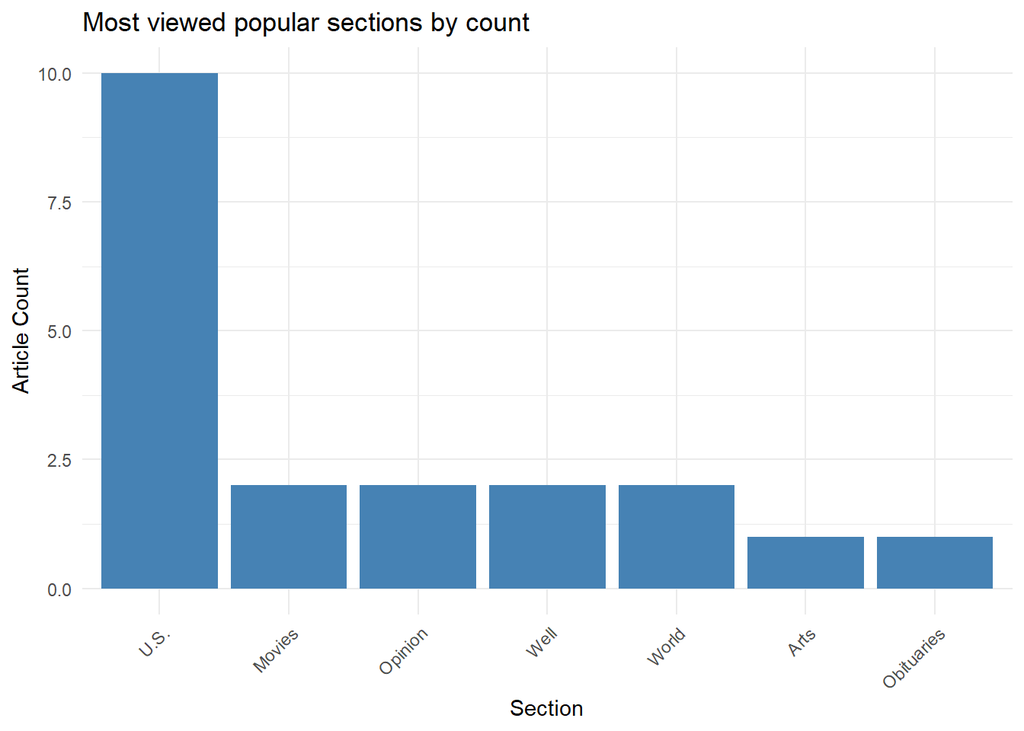

```r
ggplot(sections_df, aes(x = reorder(section, -count), y = count)) +
  geom_bar(stat = "identity", fill = "steelblue") +
  labs(title = "Most viewed popular sections by count",
       x = "Section", y = "Article Count") +
  theme_minimal() +
  theme(axis.text.x = element_text(angle = 45, hjust = 1))
```

From this plot we can say that the readers most viewed section in last 30 days is US news section.

```r
publish_day <- table(articles_df_clean$published_date)
sorted_publish_date <- sort(publish_day, decreasing = TRUE)
date_df <- as.data.frame(sorted_publish_date)
colnames(date_df) <- c("published_date", "count")
```

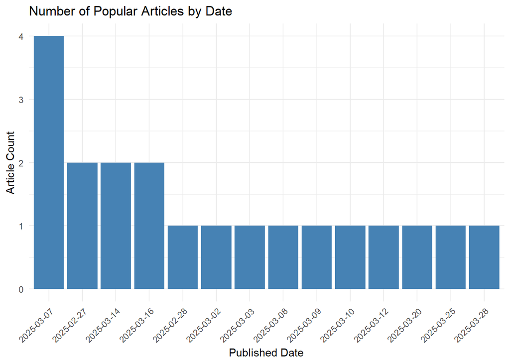

```r
ggplot(date_df, aes(x = reorder(published_date, -count), y = count)) +
  geom_bar(stat = "identity", fill = "steelblue") +
  labs(title = "Number of Popular Articles by Date",
       x = "Published Date", y = "Article Count") +
  theme_minimal() +
  theme(axis.text.x = element_text(angle = 45, hjust = 1))
```

From this chart we can see that most popular articles views day in last 30 days is March 7th, 2025